https://doi.org/10.1177/13524585211008760

https://doi.org/10.1177/13524585211008760

**MULTIPLE**

**SCLEROSIS MSJ**

**JOURNAL**

journals.sagepub.com/home/msj

29

*Multiple Sclerosis Journal*

2022, Vol. 28(1) 29 –48

DOI: 10.1177/

13524585211008760

© The Author(s), 2021.

Article reuse guidelines:

sagepub.com/journals-

permissions

**Introduction**

Multiple sclerosis (MS) is an immune-mediated neu-

rodegenerative disease of the central nervous system

(CNS) characterized by demyelination, oligodendro-

glial loss, and axonal pathology.<sup>1,2</sup> Demyelination dis-

rupts signal transmission within the CNS, causing a

gradual accumulation of physical and cognitive disa-

bility.<sup>2–4</sup> Importantly, prolonged demyelination results

in progressive axon degeneration in chronic MS

lesions.<sup>5</sup> Remyelination, the formation of new mye-

lin, is, therefore, an essential process for maintaining

the structural integrity of axons and for restoring and

maintaining

neurological

function

in

MS.<sup>6</sup>

Remyelination can occur spontaneously in demyeli-

nating plaques; however, this capacity declines in

chronic, progressive MS.<sup>6,7</sup> While the underlying

mechanisms are not fully understood, it is thought

that remyelination is incomplete in progressive MS

due to multiple factors, including the depletion of oli-

godendrocyte progenitor cells (OPCs), the reduced

ability of OPCs to differentiate into mature myelinat-

ing oligodendrocytes, and the presence of inhibitory

factors in the microenvironment of MS lesions.<sup>8–10</sup>

**Current status of neuroprotective and**

**neuroregenerative strategies in multiple**

**sclerosis: A systematic review**

**Jessica R Allanach**<sup>ǂ</sup>**, John W. Farrell III**<sup>ǂ</sup>**, Miceline Mésidor**<sup>ǂ</sup>

**and Soheila Karimi-Abdolrezaee**

*Abstract*

**Background:** Immune-mediated demyelination and consequent degeneration of oligodendrocytes and

axons are hallmark features of multiple sclerosis (MS). Remyelination declines in progressive MS, caus-

ing permanent axonal loss and irreversible disabilities. Strategies aimed at enhancing remyelination are

critical to attenuate disease progression.

**Objective:** We systematically reviewed recent advances in neuroprotective and regenerative therapies for

MS, covering preclinical and clinical studies.

**Methods:** We searched three biomedical databases using defined keywords. Two authors independently

reviewed articles for inclusion based on pre-specified criteria. The data were extracted from each study

and assessed for risk of bias.

**Results:** Our search identified 7351 studies from 2014 to 2020, of which 221 met the defined criteria.

These studies reported 262 interventions, wherein 92% were evaluated in animal models. These interven-

tions comprised protein, RNA, lipid and cellular biologics, small molecules, inorganic compounds, and

dietary and physiological interventions. Small molecules were the most highly represented strategy, fol-

lowed by antibody therapies and stem cell transplantation.

**Conclusion:** While significant strides have been made to develop regenerative treatments for MS, the

current evidence illustrates a skewed representation of the types of strategies that advance to clinical tri-

als. Further examination is thus required to address current barriers to implementing experimental treat-

ments in clinical settings.

*Keywords:* Multiple sclerosis, oligodendrocytes, demyelination, remyelination, neuroprotection,

neuroregeneration, therapeutics

Date received: 13 March 2021; revised: 13 March 2021; accepted: 21 March 2021

Correspondence to:

**S Karimi-Abdolrezaee**

Regenerative Medicine

Program, Rady Faculty

of Health Sciences,

University of Manitoba,

629-Basic Medical Sciences

Building, 745 Bannatyne

Avenue, Winnipeg,

MB R3E 0J9, Canada.

**Soheila.Karimi@**

**umanitoba.ca**

**Jessica R Allanach**

Department of Microbiology

and Immunology,

The University of British

Columbia, Vancouver,

BC, Canada

**John W. Farrell III**

Department of Health

and Human Performance,

Texas State University,

San Marcos, TX, USA

**Miceline Mésidor**

Centre de recherche du

Centre hospitalier de

l’Université de Montréal

(CRCHUM), Montréal, QC,

Canada/Department of Social

and Preventive Medicine,

Université de Montréal,

Montréal, QC, Canada

**Soheila Karimi-**

**Abdolrezaee**

Department of Physiology

and Pathophysiology,

Regenerative Medicine

Program, Rady Faculty of

Health Sciences, University

of Manitoba, Winnipeg,

MB, Canada/Children’s

Hospital Research Institute

of Manitoba, Winnipeg, MB,

Canada

ǂThese authors contributed

equally

*Original Research Paper*

*Multiple Sclerosis Journal* 28(1)

30

journals.sagepub.com/home/msj

flammation and prevent relapses.<sup>11</sup> However, these

DMTs have been notably less effective in preventing

the progression of neurodegeneration and disability in

persons with MS.<sup>12</sup>

Emphasized by the unmet need for regenerative thera-

pies for MS, the development of strategies aimed at

preventing oligodendrocyte and myelin damage, as

well as enhancing axonal remyelination and integrity,

has garnered increased recognition from researchers

and clinicians in recent years.<sup>13</sup> These strategies

include increasing trophic support for oligodendro-

cytes and axons, stimulating oligodendrogenesis,

neutralizing inhibitors of oligodendrocyte differentia-

tion and remyelination, and promoting axonal integ-

rity and regeneration, among others (Figure 1). The

purpose of the present systematic review is to provide

a timely overview of recent advancements in the

development of regenerative therapies that specifi-

cally target oligodendrogenesis and remyelination

and/or exhibit neuroprotective effects in individuals

with MS and preclinical models of disease.

**Methods**

*Search strategy*

Keywords for the search strategy were defined with

the assistance of two librarians and are presented in

Supplementary Table S1. English-written studies

were identified by searching three databases: Medical

Literature Analysis and Retrieval System Online

(MEDLINE), Evidence-Based Medicine (EBM)

Review, and Excerpta Medica dataBASE (EMBASE).

We included studies that were published from 1

January 2014 to 16 January 2020. Clinical MS studies

with measures of myelination and disability were

included. Preclinical animal studies with at least one

direct measure of myelination, oligodendrocytes, oli-

godendrocytes precursor cells, or axonal regeneration

were included. Studies that used preclinical animal

models characterized predominantly by immune-

mediated pathology (i.e. experimental autoimmune

encephalomyelitis (EAE) models) were included if

evidence was provided to indicate that the observed

neurological benefit of the intervention was not exclu-

sively a result of indirect peripheral immunomodula-

tion (e.g. effects on T cells, B cells and macrophages).

Full inclusion and exclusion criteria are listed in

Supplementary Table S2.

*Data extraction and evaluation*

Studies obtained from the queried databases were

imported into Covidence, web-based software for

systematic review management (Veritas Health

Innovation, Melbourne, Australia). For the abstract

and full-text screenings, two authors independently

evaluated each study based on the inclusion and

exclusion criteria, and, in case of disagreement, a

third author refereed. Data from all included studies

were then extracted into summary spreadsheets based

on the type of intervention, the study design, and the

measured outcomes. Finally, we assessed the risk of

bias for each study using the Cochrane Collaboration

tool<sup>14</sup> for clinical studies and the SYstematic Review

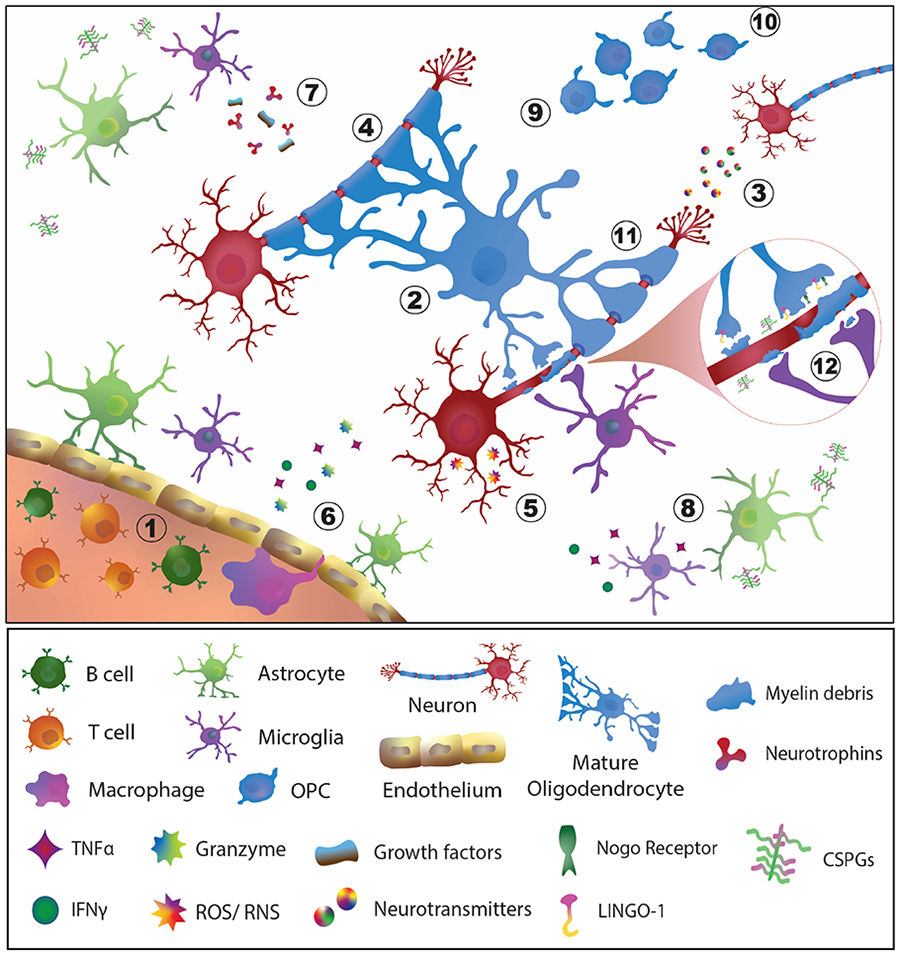

**Figure 1.** Neurodegenerative and inflammatory processes

in an MS lesion amenable to preventive and regenerative

therapies. Feasible points of intervention include: (1)

immunomodulation, the predominant strategy of currently

available therapeutics for MS; (2) promote the viability

of OPCs and oligodendrocytes; (3) preserve the quantity

and integrity of neurons and axons; (4) Protect myelin to

prevent further loss; (5) reduce oxidative stress, apoptosis

or cellular dysfunction of neurons and glial cells; (6)

promote blood–brain barrier integrity; (7) stimulate

neurotrophin and growth factor production; (8) reduce

pro-inflammatory activation of glial cells; (9) promote the

proliferation of OPCs and their differentiation into mature

myelinating oligodendrocytes; (10) induce the migration

and recruitment of OPCs and oligodendrocytes to sites of

demyelination; (11) induce the formation of new myelin;

and (12) target inhibitory factors associated with myelin

debris and promote its clearance to support remyelination

of denuded axons.

CSPGs: chondroitin sulfate proteoglycans; IFNγ: interferon

gamma; LINGO-1: leucine-rich repeat and immunoglobin-like

domain-containing protein 1; Nogo: neurite outgrowth inhibitory

protein; OPC: oligodendrocyte precursor cell; ROS: reactive

oxygen species; RNS: reactive nitrogen species; TNFα: tumor

necrosis factor alpha.

JR Allanach, JW Farrell *et al.*

journals.sagepub.com/home/msj

31

Centre for Laboratory animal Experimentation

(SYRCLE) tool<sup>15</sup> for animal studies.

**Results**

The database search resulted in 7351 studies, of

which 383 were screened at the manuscript level

(Figure 2). After assessment of the exclusion crite-

ria, 221 studies were included for data extraction

(full list provided in Supplementary Table S3).

Among the included studies, 92% were preclinical

animal studies, 7% were clinical trials, and the

remaining were observational human studies

(Figure 3). Cuprizone was the most commonly

employed agent to induce demyelination in preclin-

ical studies, followed by active EAE induction and

localized injections of lysophosphatidylcholines

(LPC, lysolecithin) or ethidium bromide (EtBr)

(Figure 3). The majority of included clinical trials

were reported in phase II. Descriptions of the

reported preclinical and clinical study designs are

noted in Supplementary Table S4.

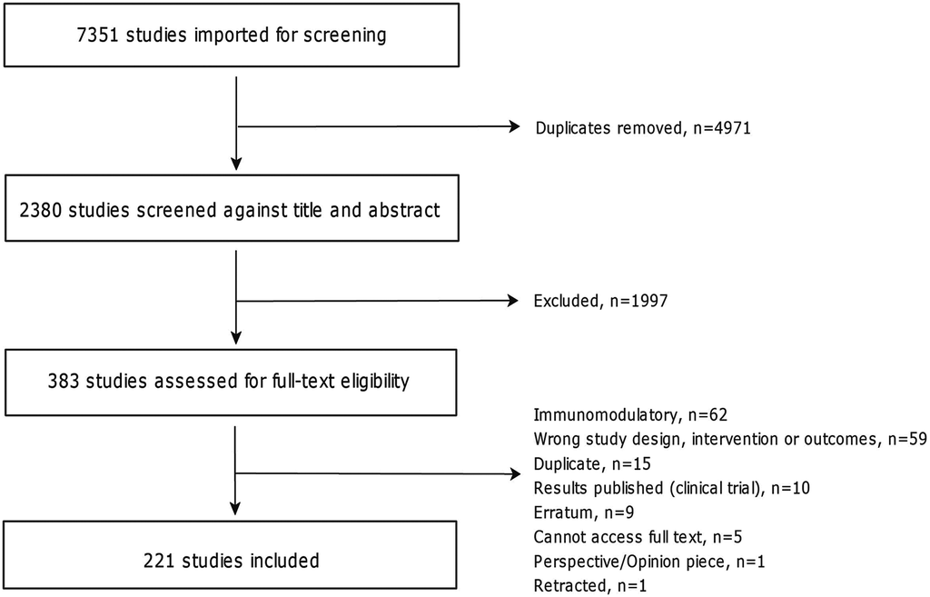

**Figure 2.** Preferred reporting items for systematic reviews and meta-analyses (PRISMA) diagram.

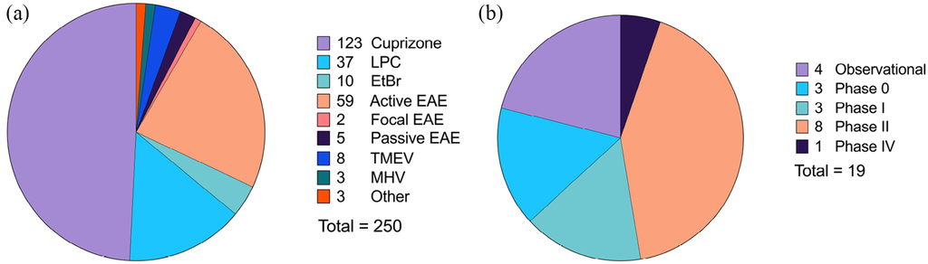

**Figure 3.** Reported preclinical models (a) and clinical trial phases (b) used to evaluate remyelinating and/or

neuroprotective interventions for MS. Among the 221 included articles, a total of 250 animal model studies and 19

clinical studies were reported. Descriptions of each study type are included in Supplementary Table S4.

EtBr: ethidium bromide; EAE: experimental autoimmune encephalomyelitis; LPC: lysophosphatidylcholine; MHV: murine hepatitis

virus; TMEV: Theiler’s murine encephalomyelitis virus.

*Multiple Sclerosis Journal* 28(1)

32

journals.sagepub.com/home/msj

**Table 1.** Quality assessment of included preclinical and clinical studies.

(A) Preclinical studies

Low risk of bias (%)

High risk of bias (%)

Was the allocation sequence adequately generated and applied?

36.0

64.0

Were the groups similar at baseline or were they adjusted for

confounders in the analysis?

98.5

1.50

Was the allocation adequately concealed?

100

0.00

Were the animals randomly housed during the experiment?

84.2

15.8

Were the caregivers and /or investigators blinded from

knowledge of which intervention each animal received during the

experiment?

4.90

95.1

Were animals selected at random for outcome assessment?

45.3

54.7

Was the outcome assessor blinded?

49.8

50.2

Were incomplete outcome data adequately addressed?

42.9

57.1

Are reports of the study free of selective outcome reporting?

75.9

24.1

Was the study apparently free of other problems that could result in

high risk of bias?

76.8

23.2

Reporting of any measure of randomization?

39.9

60.1

Reporting of any measure of blinding?

50.2

49.8

Sample size calculations provided?

3.90

96.1

Reporting of animal welfare?

97.0

3.00

Statement of a potential conflict of interest?

95.1

4.90

(B) Clinical studies

Low risk of bias (%)

High risk of bias (%)

Method of randomization used to conceal allocation sequence is

described

58.3

41.7

Allocation was concealed

50.0

50.0

Blinding of participants and personnel

58.3

41.7

Blinding of outcome assessment

58.3

41.7

Incomplete outcome data addressed

91.7

8.30

All prespecified outcomes were reported

50.0

50.0

Risk of bias was assessed for animal studies using SYRCLE’s tool (A) and for clinical studies using the Cochrane Collaboration

tool (B).

We assessed the risk of bias for animal studies using

SYRCLE’s tool (Table 1). We found no risk of bias

related to allocation concealment in preclinical stud-

ies. Similarly, we identified a low risk of bias for the

following four items: similarity of groups at baseline,

housing during the experiment, animal welfare, and

statement of potential conflicts of interest. For most

studies, however, caregivers and investigators were

not blinded from the interventions received by animals

during the experiment, and nearly 50% were not

blinded for outcome assessments. Furthermore, 60%

of studies did not report any measure of randomiza-

tion, and 96% did not report sample size calculations.

We also evaluated the risk of bias for 12 clinical trials;

the remaining clinical studies were not included

because they were abstracts or conference papers. For

most clinical studies, we found a low risk of bias

related to incomplete outcome data (Table 1). For the

other indicators, such as allocation concealment and

blinding of interventions and outcomes, we observed

blinding were more often encountered in observa-

tional human studies than in clinical trials.

A total of 262 interventions were reported within the

221 included articles. To summarize the data, inter-

ventions were categorized into eight main classes:

Small molecules, protein biologics, cellular biolog-

ics, RNA biologics, lipid biologics, dietary interven-

tions, physiological interventions, and inorganic

JR Allanach, JW Farrell *et al.*

journals.sagepub.com/home/msj

33

compounds (Figure 4). The neuroprotective and

regenerative effects of the most highly represented

interventions in each class are described in the main

text. Structural, mechanistic, and biological effects

for individual interventions within each class are

listed in Supplementary Table S5.

*Small molecules*

Administration of small organic molecules was the

most frequently reported intervention strategy, com-

prising 64.5% of all reports. Small molecules, defined

as low molecular weight compounds (<900 Daltons),

are advantageous in clinical practice due to their ease

of administration, high solubility, blood-CNS barrier

penetrance, and, often, narrow target specificity.<sup>16</sup>

Many reported small-molecule therapies are already

approved by the U.S. Food and Drug Administration

(FDA) and/or act through defined cellular mecha-

nisms. A total of 23 small-molecule therapies were

reported in two or more separate articles, which were

subcategorized into five groups based on mechanisms

of action (Tables 2–4).

*Receptor agonists and antagonists.* Treatments within

this subclass composed 41.4% of small-molecule

interventions and included eight drugs reported in two

or more separate articles (Table 2): benztropine,

clemastine fumarate, clobetasol, diarylpropionitrile,

dimethyl fumarate, fingolimod (FTY720), indazole

chloride, and laquinimod. Of note, fingolimod was the

most frequently reported drug to exhibit positive

effects on remyelination and neuroprotection, despite

some reports of null effects when administration

method and preclinical study design differed among

studies. Fingolimod is an approved immunomodula-

tory drug for relapsing-remitting MS (RRMS) that

sequesters T cells in peripheral lymph nodes by block-

ing sphingosine-1-phosphate (S1-P) receptors and

thereby suppresses autoreactive T cell migration to the

CNS.<sup>17</sup> S1-P receptors are also expressed in the brain,

where fingolimod has been shown to penetrate and

accumulate in cuprizone-treated mice.<sup>18</sup> The existing

data collectively indicate that fingolimod influences

immune-independent aspects of MS pathology, in

addition to its canonical effect on T cells. In addition,

the reported receptor modulators methylprednisolone

and GSK239512 have completed initial clinical trials

for MS. In individuals with progressive MS, methyl-

prednisolone safely improved disability and magnetic

resonance imaging (MRI) measures of disease,<sup>19</sup> while

GSK239512 treatment demonstrated a small positive

effect on lesion remyelination in people with RRMS.<sup>20</sup>

*Enzyme substrates and inhibitors.* Drugs that primarily

interacted with enzymes in key signaling or metabolic

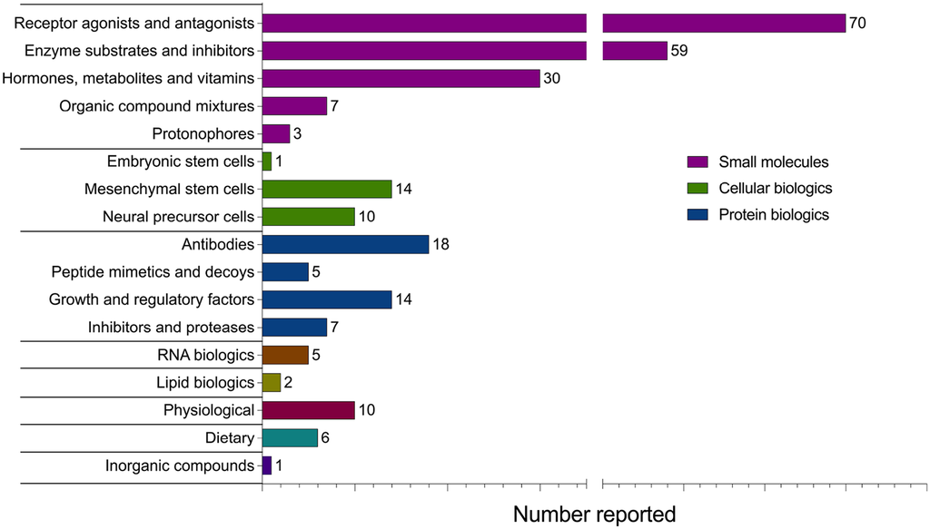

**Figure 4.** Classification of 262 interventions evaluated for neuroprotective and regenerative effects in MS patients

and preclinical models of disease. Treatments applicable to multiple classes were assigned to a single class for clarity.

Assessments of the same treatment in multiple different articles were counted as separate reports, for example,

fingolimod (FTY720) was separately studied in and counted as 11 reports.

*Multiple Sclerosis Journal* 28(1)

34

journals.sagepub.com/home/msj

**Table 2.** Neuroprotective and regenerative effects of small-molecule receptor agonists and antagonists reported in two or more separate articles.

Outcome

Benztropine*

Clemastine

fumarate*

Clobetasol*

Diaryl-

propionitrile

Dimethyl

fumarate*

Fingolimod*

(FTY720)

Indazole

chloride

Laquinimod

Increased viability of OPC and/or OLG

✓

✓

✓✓✓

✓

✓✓

Preserved quantity, function, or integrity of

neurons/axons

✓

✓

✓

✓

✓✓✓✓

✓✓

✓✓

Protected against myelin loss and/or atrophy

and lesions

✓

✓✓

✓

✓

✓✓✓✓✓

✓

✓✓

Reduced CNS oxidative stress, apoptosis, or

cellular dysfunction

✓✓

Stimulated production of neurotrophins and

growth factors

✓

✓

Suppressed inflammatory microglial and/or

astrocyte activation

✓

✓✓

✓

✓✓

Promoted NPC/OPC proliferation or

differentiation

✓

✓

✓

✓

✓✓✓✓

✓

Induced migration and recruitment of NPC/

OPC

✓✓

Induced formation of new myelin

✓

✓

✓✓

✓✓✓

✓✓

Improved neurological function (physical or

cognitive)

✓✓

✓

✓

✓

✓✓

✓✓✓

✓

Relevant miscellaneous effect

Reduced brain

S1PR1 expression

Animal models/clinical studies

Cuprizone

and EAE

Phase II

trial and

LPC

LPC, EAE,

and NMO

Cuprizone

and EAE

Cuprizone

Cuprizone, EAE,

LPC, JHMV, PTZ

seizure, and human

observational

Cuprizone

and EAE

Cuprizone

EAE: experimental autoimmune encephalomyelitis; JHMV: JHM strain of mouse hepatitis virus; LPC: lysophosphatidylcholine; NMO: neuromyelitis optica; NPC: neural precursor cell; OLG:

oligodendrocyte; OPC: oligodendrocyte precursor cell; PTZ: pentylenetetrazole; S1PR1: sphingosine-1-phosphate receptor 1.

Each check (✓) represents an observed outcome from an individual study.

*Indicates existing FDA or Health Canada approval.

JR Allanach, JW Farrell *et al.*

journals.sagepub.com/home/msj

35

**Table 3.** Neuroprotective and regenerative effects of small-molecule enzyme substrates and inhibitors reported in two or more separate articles.

Outcome

4-Aminopyridine*

BLZ945

Ellagic acid

Metformin*

Miconazole*

Nimodipine

Pregabalin*

Increased viability of OPC and/or OLG

✓

✓

✓

✓

✓

Preserved quantity, function, or integrity of neurons/axons

✓

✓

✓

✓

Protected against myelin loss and/or atrophy and lesions

✓✓

✓

✓

✓✓

✓✓

✓✓

Reduced CNS oxidative stress, apoptosis, or cellular

dysfunction

✓

✓

✓

Suppressed inflammatory microglial and/or astrocyte

activation

✓✓

✓

✓

✓

✓

Promoted NPC/OPC proliferation or differentiation

✓✓

✓

✓

Induced formation of new myelin

✓✓

✓✓

✓

✓

Increased clearance of axonal myelin debris

✓

Suppressed myelin inhibitory factors

✓

Improved neurological function (physical or cognitive)

✓✓

✓

✓

✓

✓✓

✓✓

Relevant miscellaneous effect

Changes in DTI

measures in treated

PwMS

Increased

sphingolipid levels

in spinal cord

Animal models/clinical studies

Human

observational, pilot,

and phase IV trial

Cuprizone

and EAE

Cuprizone and

EAE

Cuprizone

and EtBr

LPC, EAE,

and NMO

EAE

LPC and

EAE

DTI: diffusion tensor imaging; EAE: experimental autoimmune encephalomyelitis; EtBr: ethidium bromide; LPC: lysophosphatidylcholine; NMO: neuromyelitis optica; NPC: neural precursor cell;

OLG: oligodendrocyte; OPC: oligodendrocyte precursor cell; PwMS: persons with multiple sclerosis.

Each check (✓) represents an observed outcome from an individual study.

*Indicates existing FDA or Health Canada approval.

*Multiple Sclerosis Journal* 28(1)

36

journals.sagepub.com/home/msj

**Table 4.** Neuroprotective and regenerative effects of small-molecule hormone, metabolite, and vitamin administration reported in two or more separate articles.

Outcome

Melatonin*

Methylthioadenosine

Progesterone*

Sobetirome

T3 hormone*

Vitamin D3*

Increased viability of OPC and/or OLG

✓

✓

✓✓✓

✓✓

Preserved quantity, function, or integrity of neurons/axons

✓

✓

Protected against myelin loss and/or atrophy and lesions

✓

✓✓

✓✓

✓✓

✓✓✓

✓✓

Reduced CNS oxidative stress, apoptosis, or cellular

dysfunction

✓✓

✓✓

Suppressed inflammatory microglial and/or astrocyte activation

✓

✓✓

✓

Promoted NPC/OPC proliferation or differentiation

✓

✓

Induced migration and recruitment of NPC/OPC

✓

Induced formation of new myelin

✓

✓

Improved neurological function (physical or cognitive)

✓

✓✓

✓

✓

✓

Relevant miscellaneous effect

Increased brain sulfatide

levels; Regulated CNS

calcium proteins

Animal models/clinical studies

Cuprizone

Cuprizone

Cuprizone

Cuprizone,

LPC, and

NMO

Cuprizone

and LPC

Cuprizone and LPC

LPC: lysophosphatidylcholine; NMO: neuromyelitis optica; NPC: neural precursor cell; OLG: oligodendrocyte; OPC: oligodendrocyte precursor cell; T3: triiodothyronine.

Each check (✓) represents an observed outcome from an individual study.

*Indicates existing FDA or Health Canada approval.

JR Allanach, JW Farrell *et al.*

journals.sagepub.com/home/msj

37

pathways composed 34.9% of small-molecule reports

and included seven drugs that were reported in two or

more separate articles (Table 3): BLZ945, 4-aminopyri-

dine (Fampridine), ellagic acid, metformin, miconazole,

nimodipine, and pregabalin. In addition to these seven

inhibitors, the selective sodium-channel inhibitor and

antiepileptic drug, phenytoin, was neuroprotective of

the retinal nerve fiber layer in persons with optic neuri-

tis in a phase II trial.<sup>21</sup>

*Hormones, metabolites, and vitamins.* Among

studies that employed small molecule interven-

tions, 17.8% entailed treatment with vitamins, sim-

ple derivatives of endogenous metabolites, or

synthetic hormones/hormone mimetics. Among

them, six small molecules were reported in two or

more separate articles (Table 4): melatonin, methyl-

thioadenosine, progesterone, sobetirome, triiodo-

thyronine (T3) hormone, and vitamin D3 (calcitriol

and/or cholecalciferol).

*Protonophores.* Two articles described the neuropro-

tective effects of the protonophore MP101 (2,4-dini-

trophenol) and its prodrug, MP201, in EAE and

cuprizone animal models.<sup>22,23</sup> MP101 uncouples oxi-

dative phosphorylation in a dose-dependent manner

by enabling protons to translocate across the inner

mitochondrial membrane, which then reduces energy

production efficiency and stimulates metabolism.<sup>23</sup>

MP101/MP201 administration in the two animal

models resulted in multifaceted beneficial effects.

Treatment reduced clinical disability and visual

impairment, attenuated gliosis, promoted expression

of brain-derived neurotrophic factor (BDNF), reduced

mitochondrial dysfunction, and ameliorated myelin

and axonal damage.<sup>22,23</sup>

*Organic compound mixtures.* Interventions classified

as organic compound mixtures included composite

plant and herbal extracts, as well as culturally tradi-

tional formulations that contain multiple small mole-

cules. The reported preparations most frequently

incorporated flavonoids, terpenes, polyprenols, and

plant metabolites mimicking endogenous ligands.

Generally, the effects of the composite treatments

were ascribed to the antioxidant and anti-inflamma-

tory actions of the numerous small molecules within

the formulations. Treatment with the biflavonoid

complex Kolaviron, isolated from *Garcinia kola*

seeds, was reported in two separate studies using the

cuprizone model. The reported neuroprotective

effects included alleviation of clinical symptoms,

reduced oxidative stress, and preservation of neural

integrity in the demyelinated brain.<sup>24,25</sup> In addition,

the ∆-9-tetrahydrocannabinol (THC) and cannabidiol

(CBD)-based medication, Sativex<sup>®</sup>, improved motor

function, reduced glial scar formation, and protected

myelin and axons in a viral demyelination model.<sup>26</sup>

Sativex is currently approved by Health Canada to

treat MS neuropathic pain and spasticity in adults;

these preclinical results suggest the treatment may

also be neuroprotective.<sup>26</sup>

*Protein biologics*

Protein therapies comprised 16.8% of all reported

strategies. Five treatments were reported to have neu-

roprotective or regenerative effects in two or more

separate articles, including two antibodies, one pep-

tide mimetic, and two growth factors (Table 5).

*Antibodies.* Antibody-mediated therapies act by neu-

tralizing, depleting, or functionally blocking target

macromolecules. Antibodies designed to target and

deplete specific immune cell populations have suc-

cessfully suppressed the peripheral immune-mediated

and neuroinflammatory aspects of MS pathology in

clinical practice.<sup>27</sup> In recent years, antibody therapies

have also been developed to target neural cells and

promote regeneration. Among all included reports

from our search, the antibody treatment group con-

tained the greatest proportion of drugs that had

advanced to clinical trials (60%). Antibody therapies

that have completed at least phase I clinical trials for

MS included opicinumab (anti-LINGO-1), recombi-

nant human (rh) IgM22, anti-Nogo-A, anti-semapho-

rin-4D, elezanumab (anti-RGMa), and temelimab

(anti-pHERV-W envelope protein).

report of the approved MS immunomodulatory drug

glatiramer acetate (GA, Copaxone<sup>®</sup>). GA was evalu-

ated in an observational human trial that reported null

effects of treatment on serum BDNF levels and MRI

measures of neuroregeneration in RRMS patients.<sup>28</sup>

Two other peptide mimetics were designed to (1)

reduce glutamate-induced neuronal excitotoxicity and

(2) promote OPC differentiation and migration via

semaphorin-3A signaling in EAE and cuprizone stud-

ies, respectively.<sup>29,30</sup> In EAE and LPC animal models,

pharmacological blockade of the chondroitin sulfate

proteoglycan (CSPG) receptor, tyrosine-protein phos-

phatase sigma (PTPσ), by a synthetic domain mimic,

intracellular sigma peptide (ISP), reduced gliosis and

promoted OPC survival, proliferation, maturation,

and axon remyelination<sup>31,32</sup> (Table 5). Currently,

NVG-291, a close analog of ISP developed by Nerv-

Gen Pharma, is in preparation for clinical trials in spi-

nal cord injury and MS.<sup>31–33</sup>

*Multiple Sclerosis Journal* 28(1)

38

journals.sagepub.com/home/msj

**Table 5.** Neuroprotective and regenerative effects of protein biologics reported in two or more separate articles.

Outcome

Anti-LINGO-1

rHIgM22

Intracellular

sigma peptide

Erythropoietin*

Leukemia

inhibitory factor

Increased viability of OPC and/or OLG

✓

✓

✓

Preserved quantity, function, or integrity of neurons/axons

✓ ✓ ✓

✓

✓

Protected against myelin loss and/or atrophy and lesions

✓ ✓

✓ ✓

✓ ✓

✓

✓

Reduced CNS oxidative stress, apoptosis, or cellular dysfunction

✓

Promoted blood–brain barrier integrity

✓

Suppressed inflammatory microglial and/or astrocyte activation

✓ ✓

✓

Promoted NPC/OPC proliferation or differentiation

✓

✓ ✓

Induced formation of new myelin

✓

✓ ✓

✓ ✓

✓

Suppressed myelin inhibitory factors

✓ ✓ ✓

✓

Improved neurological function (physical or cognitive)

✓ ✓ ✓ ✓

✓

✓ ✓

Relevant miscellaneous effect

Opicinumab is safe and

tolerable in humans

Safe and tolerable in

humans

Animal models/clinical studies

LPC, EAE, optic nerve

injury, and phase II trial

Cuprizone, TMEV,

and phase I trial

LPC and EAE

Cuprizone

Cuprizone and LPC

EAE: experimental autoimmune encephalomyelitis; LPC: lysophosphatidylcholine; NPC: neural precursor cell; OLG: oligodendrocyte; OPC: oligodendrocyte precursor cell; TMEV: Theiler’s murine

encephalomyelitis virus.

Each check (✓) represents an observed outcome from an individual study.

*Indicates existing FDA or Health Canada approval.

JR Allanach, JW Farrell *et al.*

journals.sagepub.com/home/msj

39

*Growth and regulatory factors.* Among the reported

protein-based interventions, 31.8% investigated the

effects of various growth factors and regulatory pro-

teins on neurological outcomes in EAE, cuprizone,

and LPC-induced demyelination models. The major-

ity of interventions in this class involved the adminis-

tration of either hematopoietic or neurotrophic factors,

which modulated key signaling pathways regulating

immune, neuronal and glial cell activity, and survival.

The neuroregulatory effects of erythropoietin and leu-

kemia inhibitory factor were each reported in two

separate preclinical studies and are summarized in

Table 5.

*Inhibitors and proteases.* Seven studies reported ben-

eficial effects in preclinical models of MS following

treatment with protein inhibitors and proteases. Two

of these proteins were derived from animal secretions.

Apamin, a neurotoxic peptide isolated from honeybee

venom, conferred protection to myelin in the cupri-

zone model<sup>34</sup> and has completed a phase II trial for

Parkinson’s disease (NCT01341431). Ancrod, a

thrombin-like serine protease isolated from Malayan

pit viper venom, accelerated remyelination in the

LPC model.<sup>35</sup> In addition, an engineered selective

analogue and inhibitor of soluble tumor necrosis fac-

tor, XPro1595, is the focus of an ongoing phase I trial

for Alzheimer’s disease (NCT03943264). In the cupr-

izone model, XPro1595 promoted clearance of myelin

debris, which enabled earlier remyelination and ame-

liorated motor function impairments.<sup>36</sup>

*Cellular biologics*

Twenty-five reports investigated cell-based biologic

interventions in EAE and chemical demyelination

models, as well as in one human study (Table 6).

Three main groups of transplanted cells were identi-

fied in our search: mesenchymal stem cells (MSCs,

14 reports), neural or glial precursor cells (NPCs, 10

reports), and embryonic stem cells (1 report). The pre-

clinical studies obtained in our search described

numerous neuroprotective and regenerative effects of

cellular therapies (summarized in Table 6). These ani-

mal data indicate that transplanted MSCs exert bene-

ficial effects partly through their immunomodulatory

actions in the periphery when administered systemi-

cally and as they infiltrate the CNS.<sup>37</sup> By contrast, the

included phase I clinical trial of MSC transplantation

in people with RRMS and secondary progressive (SP)

MS reported no significant changes in diffusion ten-

sor imaging (DTI) parameters as a result of treat-

ment.<sup>38</sup> Among reported NPC-based therapies,

multiple strategies involved the transduction of these

cells with neurotrophic genes prior to administration

to support engraftment and differentiation to neural

lineages.<sup>39–41</sup> To date, no NPC therapy has been

approved for routine use in MS, but a number of phase

I and II trials in progressive MS are ongoing or com-

pleted (NCT03269071 and NCT03355365).

*RNA biologics*

Five reports described the use of RNA therapies in

preclinical models of MS (LPC, EtBr, cuprizone, and

EAE), wherein the treatments involved RNA-based

approaches to target inhibitors of OPC differentiation

and remyelination (Table 7). Four reports described

the neuroregenerative effects of targeting LINGO-

1<sup>42,43</sup> and Nogo-A receptor 1 (NgR1)<sup>44,45</sup> using gene

silencing approaches with small interference RNA

(siRNA) and short hairpin RNA (shRNA). An addi-

tional report evaluated the impact of administering

exogenous microRNA sequence copies in an EAE

model.<sup>46</sup> MicroRNA-146a suppresses inhibitory

signaling involved in OPC differentiation and, in this

preclinical study, supplemental treatment reduced

clinical disability, induced M2-like microglial polari-

zation, and promoted OPC differentiation and

remyelination.<sup>46</sup>

*Lipid biologics*

Two reports detailed the neurological effects of

lipid-based biologic interventions in preclinical MS

models (Table 7). The first study treated LPC-

demyelinated animals with the immunomodulatory

lipid A mimetic and toll-like receptor 4 agonist

E6020.<sup>47</sup> The second treated cuprizone-demyeli-

nated animals with ganglioside GD1a, which pro-

motes OPC maturation by inhibiting fibronectin and

integrin interactions.<sup>48</sup>

*Inorganic compounds*

A single report evaluated the therapeutic benefits of

lithium carbonate (Li2CO3) in a pilot clinical trial of

male and female participants with a progressive form

of MS.<sup>49</sup> The study assessed the safety and effects of

daily administration of low-dose Li2CO3 (concurrent

with DMTs) on disability, lesion volume, parenchy-

mal brain volume, general well-being, and relapse

rate over 1–2 years. Li2CO3 treatment was well toler-

ated and produced a nonsignificant trend toward

reduced brain atrophy and stable disability scores but

did not impact relapse rates. The authors note that

larger follow-up studies are needed to expand upon

and confirm these findings.

*Multiple Sclerosis Journal* 28(1)

40

journals.sagepub.com/home/msj

**Table 6.** Reported neuroprotective and regenerative effects of cellular biologics in animal models of MS.

Outcome

Embryonic stem cells

Mesenchymal stem cells

Neural and glial precursor cells

Cuprizone

Chemical demyelination

EAE

Chemical demyelination

EAE/Viral

Increased viability of OPC and/or OLG

✓ ✓✓

✓

Preserved quantity, function, or integrity of neurons/axons

✓ ✓ ✓

✓ ✓

✓✓✓

Protected against myelin loss and/or atrophy and lesions

✓

✓ ✓ ✓ ✓ ✓✓

✓ ✓✓

✓

✓✓✓✓✓✓✓

Reduced CNS oxidative stress, apoptosis, or cellular dysfunction

✓ ✓

✓ ✓

Stimulated production of neurotrophins and growth factors

✓ ✓

✓✓✓

Suppressed inflammatory microglial and/or astrocyte activation

✓ ✓ ✓ ✓

✓ ✓

✓✓

Promoted NPC/OPC proliferation or differentiation

✓ ✓ ✓ ✓ ✓

✓ ✓

✓✓✓

✓✓✓✓✓✓✓✓✓

Induced migration and recruitment of NPC/OPC

✓

✓ ✓

✓✓

✓✓✓

Induced formation of new myelin

✓ ✓ ✓ ✓ ✓ ✓

✓✓

✓✓✓✓

Suppressed myelin inhibitory factors

✓

Improved neurological function (physical or cognitive)

✓ ✓ ✓ ✓ ✓

✓ ✓

✓

✓✓✓✓✓✓✓

EAE: experimental autoimmune encephalomyelitis; NPC: neural precursor cell; OLG: oligodendrocyte; OPC: oligodendrocyte precursor cell.

Each check (✓) represents an observed outcome from an individual study.

**Table 7.** Reported neuroprotective and regenerative effects of RNA and lipid biologics in preclinical studies.

Outcome

Anti-LINGO-1 shRNA/siRNA

Anti-NgR1 siRNA

MicroRNA-146a mimic

E6020

GD1a ganglioside

Increased viability of OPC and/or OLG

✓

Preserved quantity, function, or integrity of neurons/axons

✓

Protected against myelin loss and/or atrophy and lesions

✓✓

✓✓

✓

Reduced CNS oxidative stress, apoptosis, or cellular dysfunction

✓

Suppressed inflammatory microglial and/or astrocyte activation

✓

✓

Promoted NPC/OPC proliferation or differentiation

✓✓

✓

✓

Induced formation of new myelin

✓

✓

Increased clearance of axonal myelin debris

✓

Suppressed myelin inhibitory factors

✓✓

✓✓

✓

Improved neurological function (physical or cognitive)

✓✓

✓

✓

Animal models/clinical studies

EtBr and EAE

LPC

EAE

LPC

Cuprizone

EAE: experimental autoimmune encephalomyelitis; EtBr: ethidium bromide; LPC: lysophosphatidylcholine; NgR1: Nogo-A receptor 1; NPC: neural precursor cell; OLG: oligodendrocyte; OPC:

oligodendrocyte precursor cell; shRNA: short hairpin RNA; siRNA: short interfering RNA.

Each check (✓) represents an observed outcome from an individual study.

JR Allanach, JW Farrell *et al.*

journals.sagepub.com/home/msj

41

*Dietary interventions*

as an alteration of the quantity of one or more compo-

nents of the diet. Two articles investigated the benefits

of enriching cuprizone rodent chow with the omega-3

fatty acids docosahexaenoic and eicosapentaenoic

acid.<sup>50,51</sup> The effects of dietary cholesterol were also

studied in EAE, cuprizone, and LPC demyelination

models.<sup>52</sup> Two additional reports evaluated the effi-

cacy of intermittent fasting in EAE, EtBr, and cupri-

zone models,<sup>53,54</sup> as well as in a pilot clinical trial

assessing feasibility for application in RRMS

(NCT01538355). The neuroprotective and regenera-

tive effects of these dietary interventions are pre-

sented in Table 8.

*Physiological and environmental interventions*

Ten reports evaluated the impact of physiological

interventions in preclinical models of MS (Table 8).

Interventions within this class covered non-pharma-

cological strategies such as exercise, electrical stimu-

lation, and modification of the environment and social

behavior. Voluntary exercise in LPC and cuprizone

models was reported to suppress glial inflammation,

promote oligodendrogenesis, and improve motor

function, among other effects.<sup>55–57</sup> The physiological

effects of exercise are wide-reaching and, similar to

dietary modifications, could be beneficial as an

adjunct therapy in MS for disease management and to

promote general well-being.

**Discussion**

The effectiveness of immunomodulatory treatments

for MS and, in particular, relapsing forms of MS, has

signified the role of neuroinflammation in disease ini-

tiation and subsequent neurodegeneration. At present,

immunomodulatory small molecule drugs and mono-

clonal antibodies are the most effective available

DMTs for the clinical management of RRMS.<sup>58</sup> The

performance of these medications in progressive

forms of MS, however, has been underwhelming and

inadequate;<sup>59</sup> a reflection of the distinct cellular pro-

cesses underlying progressive neurodegeneration as

compared to inflammatory relapses.<sup>60</sup> Transition to

secondary progressive MS over time is a common

occurrence for individuals with relapsing MS,<sup>58,59</sup>

highlighting the need for treatment strategies that

both promote CNS remyelination and protect from

further immune-mediated demyelination and degen-

eration. Our systematic review aimed to consolidate

findings from the most recent studies that have

specifically evaluated strategies devised to promote

oligodendrogenesis through recruitment and differen-

tiation of NPCs and OPCs, promote remyelination

and/or neuronal and axonal integrity, or that were able

to reduce the pro-inflammatory activity of glial cells,

expression of inhibitory factors, oxidative stress, cel-

lular dysfunction and/or apoptosis (summarized in

Figure 1). Our systematic review of the literature pro-

duced 221 articles of relevance that evaluated 262

intervention strategies in preclinical models or clini-

cal trials for MS.

The most highly represented class of treatment strate-

gies comprised small molecule drugs, followed by

antibody therapies and stem cell transplantation

(Figure 4). Interestingly, 13 of 23 small molecule

drugs that were repeatedly evaluated in the included

studies are already FDA-approved for MS or other

conditions. FDA-approved treatments can be more

readily adapted to MS and obviate resource and time-

intensive clinical trials, as they have known risk pro-

files

and

well-described

side

effects

and

counterindications. Among the included FDA-

approved small molecules identified in our search,

fingolimod was the most frequently reported drug to

exert beneficial effects on myelin integrity and repair

in several preclinical models of MS (Table 2). As fin-

golimod is a known immunomodulatory drug,<sup>58</sup> fur-

ther elucidation is required to distinguish its direct

and indirect neuroregenerative properties. Increased

knowledge of the mechanisms of action will help

determine the optimal timing and dosing of fingoli-

mod to maximize its dual benefits and ascertain its

suitability as an adjunct therapy in progressive MS.

Many reported FDA approved small molecules that

act directly on neurons and axons were adapted from

other neurological disorders to investigate their

MS-relevant effects, including pregabalin, 4-amino-

pyridine, lithium, nimodipine, benztropine, pheny-

toin, and a Sativex-like formula (Tables 2 and 3). The

MS drugs dimethyl fumarate and laquinimod both

demonstrated neuroprotective effects in cuprizone

demyelination models<sup>61–64</sup> (Table 2) and, although not

yet approved, laquinimod has completed a phase III

clinical trial for RRMS (NCT01047319). Multiple

studies reported neuroregenerative effects of small

molecule drugs that are in current use for other dis-

eases and conditions, such as clobetasol (anti-inflam-

matory),<sup>65,66</sup> clemastine fumarate (anti-allergy),<sup>55,67</sup>

miconazole (anti-fungal),<sup>65,66</sup> and metformin (anti-

diabetic).<sup>54,68,69</sup> These drugs were all reported to pro-

mote remyelination and reduce clinical disability

following chemical demyelination in preclinical stud-

ies (Tables 2 and 3). A number of reports detailed

*Multiple Sclerosis Journal* 28(1)

42

journals.sagepub.com/home/msj

**Table 8.** Reported neuroprotective and regenerative effects of dietary and physiological interventions in preclinical and clinical studies.

Outcome

Cholesterol

rich diet

Omega-3-rich

diet

Fasting

Exercise

Electroacupuncture

Environmental

enhancement

Increased viability of OPC and/or OLG

✓✓✓

✓

Preserved quantity, function, or integrity of neurons/axons

✓

✓✓

✓

✓

Protected against myelin loss and/or atrophy and lesions

✓✓✓

✓

✓

✓✓

✓

Reduced CNS oxidative stress, apoptosis, or cellular dysfunction

✓

Stimulated the production of neurotrophins and growth factors

✓

✓✓✓

✓

Suppressed inflammatory micro-glial and/or astrocyte activation

✓

✓✓

✓✓✓✓

✓

Promoted NPC/OPC proliferation or differentiation

✓

✓✓

✓

✓

Induced migration and recruitment of NPC/OPC

✓

Induced formation of new myelin

✓

✓✓

✓

Increased clearance of axonal myelin debris

✓

✓

✓

Improved neurological function (physical or cognitive)

✓

✓✓✓

✓

✓✓✓

✓✓✓

✓

Relevant miscellaneous effect

Metabolized and

incorporated into brain

biochemicals

Animal models/clinical studies

Cuprizone,

LPC, and

EAE

Cuprizone

EAE, EtBr,

cuprizone,

and pilot trial

Cuprizone

and LPC

Cuprizone, EtBr,

and EAE

Cuprizone

EAE: experimental autoimmune encephalomyelitis; EtBr: ethidium bromide; LPC: lysophosphatidylcholine; NPC: neural precursor cell; OLG: oligodendrocyte; OPC: oligodendrocyte precursor cell.

Each check (✓) represents an observed outcome from an individual study.

JR Allanach, JW Farrell *et al.*

journals.sagepub.com/home/msj

43

positive effects of organic compound mixture thera-

pies on neurological outcomes in animal models of

MS, though additional investigation will be necessary

to validate the neuroprotective and regenerative

effects of the individual components before they can

be evaluated in clinical trials.

The antibody therapies identified in our search pro-

duced multiple favorable effects in both preclinical

models and clinical trials by modulating neural and

glial targets to promote myelin repair. The recombi-

nant version of a serum-derived human IgM antibody,

rhIgM22, which is known to bind to and promote oli-

godendrocyte process outgrowth (Supplementary

Table S5F), was reported to induce remyelination and

protect neurons in cuprizone-induced demyelination

models<sup>70–72</sup> (Table 5). rhIgM22 was likewise safe and

tolerable in a phase I trial for RRMS<sup>73</sup> (NCT01803867).

Another promising protein therapy is opicinumab, the

monoclonal antibody that neutralizes the myelin

inhibitory factor LINGO-1. In preclinical models,

LINGO-1-targeted antibody therapy conferred pro-

tection to axons and enhanced remyelination<sup>74–76</sup>

(Table 5). Although opicinumab treatment was well

tolerated and safe in a phase II clinical trial, it did not

improve disability among individuals with an active

relapsing form of MS<sup>77</sup> (NCT01864148). However, in

a separate trial for individuals with optic neuritis,

Opicinumab demonstrated beneficial effects on optic

nerve function<sup>78</sup> (NCT01721161). Taken together, the

current evidence supports the pursuit of antibody-

mediated therapies as neuroprotective and neurore-

generative treatments in MS. However, additional

research will be required to confirm the clinical ben-

efits of such strategies.

Cell-based therapies are a promising approach for

stimulating repair in neurodegenerative diseases such

as MS. Transplantation of mesenchymal and CNS-

derived precursor cells has the potential to exert both

neuroprotective and neuroregenerative effects through

various mechanisms.<sup>79</sup> NPCs have the intrinsic poten-

tial to replace damaged oligodendrocytes and pro-

mote remyelination,<sup>80</sup> which is particularly important

for progressive and advanced forms of MS marked by

extensive neurodegeneration. Moreover, transplanted

NPCs can promote the repair process in the injured

CNS through paracrine effects by secreting a host of

growth factors and neurotrophins important for

endogenous oligodendrogenesis and remyelination.<sup>80</sup>

Despite their potential, the administration route for

NPCs has been a limiting factor for translational

application in MS. NPCs are most effective at cellular

replacement if delivered intra-parenchymally in the

vicinity of CNS lesions, which requires targeted

surgical intervention. Thus, more attention has been

directed to autologous MSC transplantation for the

treatment of MS, as these cells can be delivered sys-

temically

through

intravenous

or

intrathecal

routes.<sup>79,81</sup> Overall, cellular biologic therapies are

considered a technically complicated approach with a

greater risk of adverse effects, thus requiring addi-

tional optimization before widespread use in clinical

practice.<sup>82</sup>

Pharmaceuticals that affect lipid metabolism, and

therefore potentially myelin formation, are logical

candidates for therapeutic development in MS. Our

search identified several such candidates, including

sobetirome,<sup>66,83</sup> T3 hormone<sup>83–85</sup> (Table 4), ellagic

acid<sup>86,87</sup> (Table 3), the protonophore MP101/201,<sup>22,23</sup>

and the lipids E6020<sup>47</sup> and GD1a ganglioside<sup>48</sup> (Table

7). Furthermore, the positive effects of some dietary

interventions were ascribed at least in part to altera-

tions of metabolism, including vitamin and metabolite

supplementation (Table 4), dietary cholesterol<sup>52</sup> and

omega-3 fatty acid enrichment,<sup>50,51</sup> and the application

of intermittent fasting<sup>53,54</sup> (Table 8). Studies included

in our search that employed dietary or physiological

interventions were underrepresented as compared to

pharmaceutical-based strategies. Nevertheless, non-

pharmacological treatments are being increasingly

recognized as valuable adjunct interventions when

designing comprehensive neuroregenerative thera-

pies.<sup>88,89</sup> Exercise, socialization, and nutritional modi-

fications demonstrated both neuroprotective and

regenerative effects in animal models of MS<sup>55–57,90,91</sup>

(Tables 7 and 8), and the many beneficial effects of

plant-derived organic compound formulations<sup>24–26,92–95</sup>

further supports integrating dietary modifications into

MS treatment regimens. Although many non-pharma-

cological strategies are multifactorial, and are there-

fore more difficult to evaluate for direct effects on

specific outcomes in individuals with MS, their mini-

mal associated risks and practical ease of implementa-

tion are attractive features for use in the management

of MS. The success of these strategies, however,

requires the provision of clear and consistent evidence-

based recommendations practiced under the supervi-

sion of qualified professionals in order for persons

with MS to make therapeutically effective dietary and

lifestyle modifications that encourage adherence.<sup>96,97</sup>

Importantly, non-pharmacological strategies can be

less financially burdensome than many standard

DMTs. Given that the cost of monoclonal antibody

therapies, such as ocrelizumab and natalizumab, is

estimated at $30,000 per annum in Canada,<sup>98</sup> the inclu-

sion of non-pharmacological approaches could partly

reduce the economic hurdle of achieving therapeuti-

cally significant results. As such, socioeconomic

*Multiple Sclerosis Journal* 28(1)

44

journals.sagepub.com/home/msj

considerations informed by the demographic data of

individuals with MS should be accounted for in the

selection of preclinical strategies for clinical develop-

ment to provide inclusive access to treatment.

Perhaps, unsurprisingly, the vast majority of data

included in our screen was obtained from preclinical

animal models, representing over 90% of the study

designs (Figure 3). Among the available experimental

models for MS, chemical demyelination methods

(cuprizone, LPC, and EtBr) were employed in the

majority of studies. The advantage of these models is

that demyelination and remyelination occur in tempo-

rally reproducible patterns with minimal involvement

of peripheral immune cells (Supplementary Table

S4). Despite their advantages, the pitfalls and applica-

bility of established animal models of MS is an ongo-

ing topic of discussion concerning translation to

clinical practice.<sup>99</sup> Reported methods used in the

included preclinical studies to dissect mechanism

often lacked clear feasibility for translation due to

invasive or complicated administration protocols and

high doses or frequency of treatments. The lack of

reporting of tolerability and potential adverse side

effects that are either undetectable in some animal

models or that are overlooked in the early stages of

drug identification was also concerning. Moreover,

there was a consistent risk of bias among preclinical

and clinical studies related to the reporting of treat-

ment and outcome blinding and sample size calcula-

tions (Table 1). These are critical gaps, in particular,

for consistent evaluation of behavioral and clinical

outcomes, which are largely subjective and can be

prone to unconscious bias.<sup>100</sup> The creation of stand-

ardized protocols for randomization, blinding, treat-

ment endpoints, and effective methods for assessing

regenerative treatment safety and efficacy in preclini-

cal MS models could substantially reduce variability,

ambiguity, and bias in reporting.<sup>101</sup> These preclinical

measures would also augment reproducibility and the

level of evidence needed to justify advancement to

resource-intensive clinical trials. While blinding

measures were more thoroughly reported in clinical

trial designs, more sensitive and precise imaging

techniques are needed to directly monitor and meas-

ure the efficacy of remyelinating therapies in individ-

uals with MS over time.<sup>102</sup>

In conclusion, the increasing number of studies that

have recently evaluated neuroprotective and neu-

roregenerative interventions in MS underscores the

shared impetus of researchers and clinicians to

address the unmet need for effective treatments in

late-stage and progressive MS. Although there has

been considerable progress in this area, the collec-

tive data illustrate a skewed representation of the

types of strategies that advance from preclinical

models to clinical trials that heavily favors antibody

and small molecule-based therapies over other inter-

vention types. This may be due to the inherent issues

in the administration of other potential therapeutic

strategies (e.g. diet and exercise) in a controlled trial

design that may lead to difficulties in the interpreta-

tion of results. In addition, our findings point to

inherent challenges in translating the outcomes of

animal studies, as well as to practical barriers to

assessing and implementing experimental treatments

in clinical settings. Accordingly, further research is

required to address the challenges of translating pre-

clinical findings.

**Author Contributions**

M.M. designed the search strategy, composed key-

word strings, and identified articles from queried

databases. J.F. and J.R.A. served as reviewers for arti-

cle screening. J.F. composed the background informa-

tion. M.M., J.F., and J.R.A. performed data extraction.

J.R.A. compiled extracted data and summarized

results. S.K.-A. conceptualized the review, oversaw

manuscript preparation, and interpreted results for

discussion.

**Declaration of Conflicting Interests**

The author(s) declared no potential conflicts of inter-

est with respect to the research, authorship, and/or

publication of this article.

**Funding**

The author(s) disclosed receipt of the following financial

support for the research, authorship, and/or publication of

this article: This study was supported by the endMS

Research and Training Network, Scholar Program for

Researchers in Training (SPRINT), and the MS Society

of Canada. J.R.A. is supported by an endMS Doctoral

Studentship Award from the MS Society of Canada. J.F.

is supported by the uOttawa/Children’s Hospital of

Eastern Ontario Research Institute Collaborative

Initiative Postdoctoral Fellowship. M.M. is supported by

the Fonds de Recherche du Québec-Santé (FRQS) PhD

fellowship. S.K.-A is supported by the MS Society of

Canada (EGID-3742) and the Canadian Institute of

Health Research (Grant ID 156218).

**Supplemental material**

Supplemental material for this article is available

online.

JR Allanach, JW Farrell *et al.*

journals.sagepub.com/home/msj

45

<sup>**References**</sup>

1. Dua TRP. *Atlas: Multiple sclerosis resources in the*

*world*. Geneva: World Health Organization, 2008.

2. Trapp BD and Nave KA. Multiple sclerosis: An

immune or neurodegenerative disorder? *Annu Rev*

*Neurosci* 2008; 31: 247–269.

3. Baird JF, Cederberg KLJ, Sikes EM, et al. Physical

activity and walking performance across the lifespan

among adults with multiple sclerosis. *Mult Scler*

*Relat Disord* 2019; 35: 36–41.

4. Benedict RHB, Amato MP, DeLuca J, et al.

Cognitive impairment in multiple sclerosis: Clinical

management, MRI, and therapeutic avenues. *Lancet*

*Neurol* 2020; 19(10): 860–871.

5. Lubetzki C, Zalc B, Williams A, et al. Remyelination

in multiple sclerosis: From basic science to clinical

translation. *Lancet Neurol* 2020; 19(8): 678–688.

6. Plemel JR, Liu WQ and Yong VW. Remyelination

therapies: A new direction and challenge in multiple

sclerosis. *Nat Rev Drug Discov* 2017; 16(9): 617–634.

7. Kremer D, Gottle P, Flores-Rivera J, et al.

Remyelination in multiple sclerosis: From concept

to clinical trials. *Curr Opin Neurol* 2019; 32(3):

378–384.

8. Kuhlmann T, Miron V, Cui Q, et al. Differentiation

block of oligodendroglial progenitor cells as a

cause for remyelination failure in chronic multiple

sclerosis. *Brain* 2008; 131(Pt. 7): 1749–1758.

9. Cui QL, Kuhlmann T, Miron VE, et al.

Oligodendrocyte progenitor cell susceptibility to

injury in multiple sclerosis. *Am J Pathol* 2013;

183(2): 516–525.

10. Pu A, Stephenson EL and Yong VW. The

extracellular matrix: Focus on oligodendrocyte

biology and targeting CSPGs for remyelination

therapies. *Glia* 2018; 66(9): 1809–1825.

11. Thompson AJ. Commentary on the ECTRIMS-

EAN guideline for pharmacological treatment of

multiple sclerosis. *Ther Adv Neurol Disord* 2018;

11: 1–2.

12. Ineichen BV, Plattner PS, Good N, et al. Nogo-A

antibodies for progressive multiple sclerosis. *CNS*

*Drugs* 2017; 31(3): 187–198.

13. Kremer D, Gottle P, Hartung HP, et al. Pushing

Forward: Remyelination as the New Frontier in CNS

Diseases. *Trends Neurosci* 2016; 39(4): 246–263.

14. Higgins JP, Altman DG, Gotzsche PC, et al. The

Cochrane Collaboration’s tool for assessing risk of

bias in randomised trials. *BMJ* 2011; 343: d5928.

15. Hooijmans CR, Rovers MM, de Vries RB, et al.

SYRCLE’s risk of bias tool for animal studies. *BMC*

*Med Res Methodol* 2014; 14: 43.

16. Pajouhesh H and Lenz GR. Medicinal chemical

properties of successful central nervous system

drugs. *Neurorx* 2005; 2(4): 541–553.

17. Chun J and Hartung HP. Mechanism of action of

oral fingolimod (FTY720) in multiple sclerosis. *Clin*

*Neuropharmacol* 2010; 33: 91–101.

18. Kim S, Bielawski J, Yang H, et al. Functional

antagonism of sphingosine-1-phosphate receptor

1 prevents cuprizone-induced demyelination. *Glia*

2018; 66(3): 654–669.

19. Ratzer R, Iversen P, Bornsen L, et al. Monthly oral

methylprednisolone pulse treatment in progressive

multiple sclerosis. *Mult Scler* 2016; 22(7): 926–934.

20. Schwartzbach CJ, Grove RA, Brown R, et al. Lesion

remyelinating activity of GSK239512 versus

placebo in patients with relapsing-remitting multiple

sclerosis: A randomised, single-blind, phase II study.

*J Neurol* 2017; 264(2): 304–315.

21. Raftopoulos R, Hickman SJ, Toosy A, et al.

Phenytoin for neuroprotection in patients with acute

optic neuritis: A randomised, placebo-controlled,

phase 2 trial. *Lancet Neurol* 2016; 15(3): 259–269.

22. Bando Y and Geisler JG. Disease modifying

mitochondrial uncouplers, MP101, and a slow

release ProDrug, MP201, in models of Multiple

Sclerosis. *Neurochem Int* 2019; 131: 104561.

23. Khan RS, Dine K, Geisler JG, et al. Mitochondrial

Uncoupler Prodrug of 2,4-Dinitrophenol, MP201,

Prevents Neuronal Damage and Preserves Vision in

Experimental Optic Neuritis. *Oxid Med Cell Longev*

2017; 2017: 7180632.

24. Omotoso GO, Ukwubile Arietarhire L, Sulaimon

F, et al. Kolaviron protects the brain in cuprizone-

induced model of experimental multiple sclerosis via

enhancement of intrinsic antioxidant mechanisms:

Possible therapeutic applications. *Pathophysiology*

2018; 25(4): 299–306.

25. Omotoso GO, Olajide OJ, Gbadamosi IT, et al.

Kolaviron protects the prefrontal cortex and

hippocampus against histomorphological and

neurobehavioural changes in cuprizone model of

multiple sclerosis. *Malays J Med Sci* 2018; 25(2):

50–63.

26. Feliu A, Moreno-Martet M, Mecha M, et al. A

Sativex((R)) -like combination of phytocannabinoids

as a disease-modifying therapy in a viral model

of multiple sclerosis. *Br J Pharmacol* 2015; 172:

3579–3595.

27. Voge NV and Alvarez E. Monoclonal antibodies in

multiple sclerosis: Present and future. *Biomedicines*

2019; 7: 20.

28. Ehling R, Di Pauli F, Lackner P, et al. Impact

of glatiramer acetate on paraclinical markers of

*Multiple Sclerosis Journal* 28(1)

46

journals.sagepub.com/home/msj

neuroprotection in multiple sclerosis: A prospective

observational clinical trial. *J Neuroimmunol* 2015;

287: 98–105.

29. Biname F, Pham-Van LD, Spenle C, et al. Disruption

of Sema3A/Plexin-A1 inhibitory signalling in

oligodendrocytes as a therapeutic strategy to promote

remyelination. *EMBO Mol Med* 2019; 11: e10378.

30. Zhai D, Lee FH, D’Souza C, et al. Blocking GluR2-

GAPDH ameliorates experimental autoimmune

encephalomyelitis. *Ann Clin Transl Neurol* 2015;

2(4): 388–400.

31. Luo F, Tran AP, Xin L, et al. Modulation of

proteoglycan receptor PTPsigma enhances MMP-2

activity to promote recovery from multiple sclerosis.

*Nat Commun* 2018; 9: 4126.

32. Niknam P, Raoufy MR, Fathollahi Y, et al.

Modulating proteoglycan receptor PTPsigma using

intracellular sigma peptide improves remyelination

and functional recovery in mice with demyelinated

optic chiasm. *Mol Cell Neurosci* 2019; 99: 103391.

33. Carvalho J. NervGen Planning Clinical Trials of

NVG-291, Peptide That Might Promote Myelin

Repair, https://multiplesclerosisnewstoday.com/

news-posts/2019/09/06/nervgen-planning-clinical-

trials-nvg-291-peptide-promoting-myelin-repair/

(2019, accessed 12 March 2021).

34. Mohammadi-Rad M, Ghasemi N and Aliomrani M.

Evaluation of apamin effects on myelination process

in C57BL/6 mice model of multiple sclerosis. *Res*

*Pharm Sci* 2019; 14(5): 424–431.

35. Petersen MA, Ryu JK, Chang KJ, et al. Fibrinogen

activates bmp signaling in oligodendrocyte progenitor

cells and inhibits remyelination after vascular damage.

*Neuron* 2017; 96: 1003. e1007–1003. e1012.

36. Karamita M, Barnum C, Mobius W, et al.

Therapeutic inhibition of soluble brain TNF

promotes remyelination by increasing myelin

phagocytosis by microglia. *JCI Insight* 2017; 2:

e87455.

37. Gao F, Chiu SM, Motan DA, et al. Mesenchymal

stem cells and immunomodulation: Current status

and future prospects. *Cell Death Dis* 2016; 7: e2062.

38. Feng JLJ, Sakaie K, Planchon S, et al. Using

diffusion tensor imaging to quantify effects of

autologous mesenchymal stem cell transplantation

in multiple sclerosis patients. *Neurology* 2017; 88:

P5345.

39. Gao X, Deng L, Wang Y, et al. GDNF enhances

therapeutic efficiency of neural stem cells-

based therapy in chronic experimental allergic

encephalomyelitis in rat. *Stem Cells Int* 2016; 2016:

1431349.

40. Li X, Zhang Y, Yan Y, et al. LINGO-1-Fc-transduced

neural stem cells are effective therapy for chronic

stage experimental autoimmune encephalomyelitis.

*Mol Neurobiol* 2017; 54(6): 4365–4378.

41. Razavi S, Ghasemi N, Mardani M, et al.

Co-Transplantation of human neurotrophic factor

secreting cells and adipose-derived stem cells in rat

model of multiple sclerosis. *Cell J* 2018; 20(1): 46–52.

42. Wang CJ, Qu CQ, Zhang J, et al. Lingo-1 inhibited

by RNA interference promotes functional recovery

of experimental autoimmune encephalomyelitis.

*Anat Rec (Hoboken)* 2014; 297(12): 2356–2363.

43. Youssef AEH, Dief AE, El Azhary NM, et al. LINGO-1

siRNA nanoparticles promote central remyelination

in ethidium bromide-induced demyelination in rats. *J*

*Physiol Biochem* 2019; 75(1): 89–99.

44. Pourabdolhossein F, Mozafari S, Morvan-Dubois

G, et al. Nogo receptor inhibition enhances

functional recovery following lysolecithin-induced

demyelination in mouse optic chiasm. *PLoS ONE*

2014; 9(9): e106378.

45. Pourabdolhossein FDS, Demeneix B and Javan M. Nogo

receptor blockade enhances subventricular zone’s stem

cells proliferation and differentiation in demyelination

context. *Physiol Pharmacol* 2017; 21: 193–205.

46. Zhang J, Zhang ZG, Lu M, et al. MiR-146a promotes

oligodendrocyte progenitor cell differentiation and

enhances remyelination in a model of experimental

autoimmune encephalomyelitis. *Neurobiol Dis* 2019;

125: 154–162.

47. Church JS, Milich LM, Lerch JK, et al. E6020,

a synthetic TLR4 agonist, accelerates myelin

debris clearance, Schwann cell infiltration, and

remyelination in the rat spinal cord. *Glia* 2017;

65(6): 883–899.

48. Qin J, Sikkema AH, van der Bij K, et al. GD1a

Overcomes Inhibition of Myelination by

Fibronectin via Activation of Protein Kinase A:

Implications for Multiple Sclerosis. *J Neurosci*

2017; 37: 9925–9938.

49. Rinker JR, Sung V, Nicholas A, et al. A pilot study of

lithium in progressive multiple sclerosis. In: Library

EO (ed.) *European Committee for Treatment and*

*Research in Multiple Sclerosis*. New York: Springer,

2016, pp. 23.

50. Chen S, Zhang H, Pu H, et al. n-3 PUFA

supplementation benefits microglial responses to

myelin pathology. *Sci Rep* 2014; 4: 7458.

51. Di Biase A, Salvati S, Di Benedetto R, et al.

Eicosapentaenoic acid pre-treatment reduces

biochemical changes induced in total brain and

myelin of weanling Wistar rats by cuprizone feeding.

*Prostaglandins Leukot Essent Fatty Acids* 2014;

90(4): 99–104.

52. Berghoff SA, Gerndt N, Winchenbach J, et al.

Dietary cholesterol promotes repair of demyelinated

JR Allanach, JW Farrell *et al.*

journals.sagepub.com/home/msj

47

lesions in the adult brain. *Nat Commun* 2017; 8:

14241.

53. Choi IY, Piccio L, Childress P, et al. A diet

mimicking fasting promotes regeneration and

reduces autoimmunity and multiple sclerosis

symptoms. *Cell Rep* 2016; 15: 2136–2146.

54. Neumann B, Baror R, Zhao C, et al. Metformin

restores CNS remyelination capacity by rejuvenating

aged stem cells. *Cell Stem Cell* 2019; 25: 473.

e478–473. e485.

55. Jensen SK, Michaels NJ, Ilyntskyy S, et al.

Multimodal enhancement of remyelination by

exercise with a pivotal role for oligodendroglial

PGC1alpha. *Cell Rep* 2018; 24: 3167–3179.

56. Mandolesi G, Bullitta S, Fresegna D, et al. Voluntary

running wheel attenuates motor deterioration and

brain damage in cuprizone-induced demyelination.

*Neurobiol Dis* 2019; 129: 102–117.

57. Naghibzadeh M, Ranjbar R, Tabandeh MR, et al.

Effects of two training programs on transcriptional

levels of neurotrophins and glial cells population in

hippocampus of experimental multiple sclerosis. *Int*

*J Sports Med* 2018; 39(8): 604–612.

58. Kamm CP, Uitdehaag BM and Polman CH. Multiple

sclerosis: Current knowledge and future outlook. *Eur*

*Neurol* 2014; 72(3-4): 132–141.

59. Baldassari LE and Fox RJ. Therapeutic advances and

challenges in the treatment of progressive multiple

sclerosis. *Drugs* 2018; 78(15): 1549–1566.

60. Dutta R and Trapp BD. Relapsing and progressive

forms of multiple sclerosis: Insights from pathology.

*Curr Opin Neurol* 2014; 27(3): 271–278.

61. Cerina M, Narayanan V, Delank A, et al. Protective

potential of dimethyl fumarate in a mouse model of

thalamocortical demyelination. *Brain Struct Funct*

2018; 223(7): 3091–3106.

62. Kramann N, Menken L, Hayardeny L, et al. Laquinimod

prevents cuprizone-induced demyelination independent

of Toll-like receptor signaling. *Neurol Neuroimmunol*

*Neuroinflamm* 2016; 3(3): e233.

63. Kumar P, Sharma G, Gupta V, et al. Preclinical

explorative assessment of dimethyl fumarate-

based biocompatible nanolipoidal carriers for the

management of multiple sclerosis. *ACS Chem*

*Neurosci* 2018; 9: 1152–1158.

64. Nyamoya S, Steinle J, Chrzanowski U, et al.

Laquinimod supports remyelination in non-

supportive environments. *Cells* 2019; 8: 1363.

65. Navarrete C, Carrillo-Salinas F, Palomares B, et al.

Hypoxia mimetic activity of VCE-004.8, a cannabidiol

quinone derivative: Implications for multiple sclerosis

therapy. *J Neuroinflammation* 2018; 15: 64.

66. Yao X, Su T and Verkman AS. Clobetasol promotes

remyelination in a mouse model of neuromyelitis

optica. *Acta Neuropathol Commun* 2016; 4: 42.

67. Green AJ, Gelfand JM, Cree BA, et al. Clemastine

fumarate as a remyelinating therapy for multiple

sclerosis (ReBUILD): A randomised, controlled,

double-blind, crossover trial. *Lancet* 2017; 390:

2481–2489.

68. Alazrag HA, Abdelghaffar ME, Khalifa HM, et

al. The role of LINGO-1 and myelin basic protein

mRNAs in central remyelination in ethidium

bromide-induced demyelination in rats. *Asian*

*Journal of Pharmaceutical and Clinical Research*

2019; 12: 143–150.

69. Largani SHH, Borhani-Haghighi M, Pasbakhsh P, et

al. Oligoprotective effect of metformin through the

AMPK-dependent on restoration of mitochondrial

hemostasis in the cuprizone-induced multiple

sclerosis model. *J Mol Histol* 2019; 50(3): 263–271.

70. Cui C, Wang J, Mullin AP, et al. The antibody rHIgM22

facilitates hippocampal remyelination and ameliorates

memory deficits in the cuprizone mouse model of

demyelination. *Brain Res* 2018; 1694: 73–86.

71. Mullin AP, Cui C, Wang Y, et al. rHIgM22 enhances

remyelination in the brain of the cuprizone mouse

model of demyelination. *Neurobiol Dis* 2017; 105:

142–155.

72. Wootla B, Denic A, Watzlawik JO, et al. Antibody-

mediated oligodendrocyte remyelination promotes

axon health in progressive demyelinating disease.

*Mol Neurobiol* 2016; 53(8): 5217–5228.

73. Eisen A, Greenberg BM, Bowen JD, et al. A double-

blind, placebo-controlled, single ascending-dose

study of remyelinating antibody rHIgM22 in people

with multiple sclerosis. *Mult Scler J Exp Transl Clin*

2017; 3(4): 2055217317743097.

74. Gresle MM, Liu Y, Kilpatrick TJ, et al. Blocking

LINGO-1 in vivo reduces degeneration and enhances

regeneration of the optic nerve. *Mult Scler J Exp*

*Transl Clin* 2016; 2: 2055217316641704.

75. Zhang Y, Zhang YP, Pepinsky B, et al. Inhibition

of LINGO-1 promotes functional recovery after

experimental spinal cord demyelination. *Exp Neurol*

2015; 266: 68–73.

76. Mellion M, Edwards KR, Hupperts R, et al. Efficacy

results from the Phase 2b SYNERGY study:

Treatment of disabling multiple sclerosis with the

anti-LINGO-1 monoclonal antibody opicinumab

(S33.004). *Neurology* 2017; 88: S33.

77. Cadavid D, Mellion M, Hupperts R, et al. Safety and

efficacy of opicinumab in patients with relapsing

multiple sclerosis (SYNERGY): A randomised,

placebo-controlled, phase 2 trial. *Lancet Neurol*

2019; 18(9): 845–856.

*Multiple Sclerosis Journal* 28(1)

48

journals.sagepub.com/home/msj

78. Freeman S, Vanopdenbosch L, Butzkueven H, et al.

Safety and tolerability of anti-LINGO-1 monoclonal

antibody BIIB033 in acute optic neuritis: The

RENEW trial. *Neurology* 2015; 84: P7203.

79. Scolding NJ, Pasquini M, Reingold SC, et al. Cell-

based therapeutic strategies for multiple sclerosis.

*Brain* 2017; 140: 2776–2796.

80. Vishwakarma SK, Bardia A, Tiwari SK, et al.

Current concept in neural regeneration research:

NSCs isolation, characterization and transplantation

in various neurodegenerative diseases and stroke: A

review. *J Adv Res* 2014; 5(3): 277–294.

81. Cohen JA. Mesenchymal stem cell transplantation in

multiple sclerosis. *J Neurol Sci* 2013; 333: 43–49.

82. Cuascut FX and Hutton GJ. Stem cell-based

therapies for multiple sclerosis: Current perspectives.

*Biomedicines* 2019; 7: 26.

83. Hartley MD, Banerji T, Tagge IJ, et al. Myelin repair

stimulated by CNS-selective thyroid hormone action.

*JCI Insight* 2019; 4: e126329.

84. Zendedel A, Kashani IR, Azimzadeh M, et al. Regulatory

effect of triiodothyronine on brain myelination and

astrogliosis after cuprizone-induced demyelination in

mice. *Metab Brain Dis* 2016; 31(2): 425–433.

85. Zhang M, Zhan XL, Ma ZY, et al. Thyroid hormone

alleviates demyelination induced by cuprizone through

its role in remyelination during the remission period.

*Exp Biol Med (Maywood)* 2015; 240(9): 1183–1196.

86. Busto R, Serna J, Perianes-Cachero A, et al. Ellagic

acid protects from myelin-associated sphingolipid

loss in experimental autoimmune encephalomyelitis.

*Biochim Biophys Acta Mol Cell Biol Lipids* 2018;

1863(9): 958–967.

87. Sanadgol N, Golab F, Tashakkor Z, et al.

Neuroprotective effects of ellagic acid on cuprizone-

induced acute demyelination through limitation of

microgliosis, adjustment of CXCL12/IL-17/IL-11

axis and restriction of mature oligodendrocytes

apoptosis. *Pharm Biol* 2017; 55(1): 1679–1687.

88. Namjooyan F, Ghanavati R, Majdinasab N, et al.

Uses of complementary and alternative medicine in

multiple sclerosis. *J Tradit Complement Med* 2014;

4(3): 145–152.

89. Koriem KMM. Multiple sclerosis: New insights and

trends. *Asian Pacific J Tropical Biomed* 2016; 6:

429–440.

90. Mohamed A, Al-Kafaji G, Almahroos A, et al.

Effects of enhanced environment and induced

depression on cuprizone mouse model of

demyelination. *Exp Ther Med* 2019; 18(1): 566–572.

91. Makinodan M, Ikawa D, Miyamoto Y, et al. Social

isolation impairs remyelination in mice through

modulation of IL-6. *FASEB J* 2016; 30(12):

4267–4274.

92. Carvalho FB, Gutierres JM, Bohnert C, et

al. Anthocyanins suppress the secretion of

proinflammatory mediators and oxidative stress, and

restore ion pump activities in demyelination. *J Nutr*

*Biochem* 2015; 26(4): 378–390.

93. Neelamma G, Duraiswamy B, Suresh NS, et al.

Evaluation of protective neuro pharmacological

activity of seeds of cucurbita maxima against

ethidium bromide induced demyelination in rat

model. *Int J Pharm Sci Rev Res* 2018; 48: 83–91.

94. Liang M, Chen Y, Zhang L, et al. Epimedium

flavonoids ameliorate neuropathological changes

and increases IGF-1 expression in C57BL/6 mice

exposed to cuprizone. *Neurochem Res* 2015; 40(3):

492–500.

95. Khodanovich MY, Pishchelko AO, Glazacheva VY,

et al. Plant polyprenols reduce demyelination and

recover impaired oligodendrogenesis and neurogenesis

in the cuprizone murine model of multiple sclerosis.

*Phytother Res* 2019; 33(5): 1363–1373.

96. Riemann-Lorenz K, Eilers M, von Geldern G, et

al. Dietary interventions in multiple sclerosis:

Development and pilot-testing of an evidence based

patient education program. *PLoS ONE* 2016; 11(10):

e0165246.

97. Heesen C, Bruce J, Gearing R, et al. Adherence

to behavioural interventions in multiple sclerosis:

Follow-up meeting report (AD@MS-2). *Mult Scler J*

*Exp Transl Clin* 2015; 1: 2055217315585333.

98. Multiple Sclerosis International Federation. Ocrevus,

https://mssociety.ca/managing-ms/treatments/

medications/disease-modifying-therapies-dmts/

ocrevus (2021, accessed December 10 2020).

99. Lassmann H and Bradl M. Multiple sclerosis:

Experimental models and reality. *Acta Neuropathol*

2017; 133(2): 223–244.

100. Bello S, Krogsboll LT, Gruber J, et al. Lack of

blinding of outcome assessors in animal model

experiments implies risk of observer bias. *J Clin*

*Epidemiol* 2014; 67(9): 973–983.

101. Ferreira GS, Veening-Griffioen DH, Boon WPC,

et al. A standardised framework to identify

optimal animal models for efficacy assessment

in drug development. *PLoS ONE* 2019; 14:

e0218014.

102. O’Muircheartaigh J, Vavasour I, Ljungberg E, et al.

Quantitative neuroimaging measures of myelin in the

healthy brain and in multiple sclerosis. *Hum Brain*

*Mapp* 2019; 40(7): 2104–2116.

Visit SAGE journals online

journals.sagepub.com/

home/msj

SAGE journals